# R강의3-기본적인 통계

문건웅

# 지난 주 숙제

(문제) 학생 10명이 있다.영어 시험 결과를 eng, 수학 시험 결과를 math라고 하자. 영어시험은 2번과 9번 학생이 결시하였고 9번 학생이 수학시험을 결시하였다. R에서 결측치는 NA이다.

```r
번호=1:10
영어=c(70,NA,80,85,90,90,60,55,NA,90)
수학=c(80,73,84,90,95,85,60,50,NA,100)
data=data.frame(번호,영어,수학)
data
```

```
   번호 영어 수학
1     1   70   80
2     2   NA   73
3     3   80   84
4     4   85   90
5     5   90   95
6     6   90   85
7     7   60   60
8     8   55   50
9     9   NA   NA
10   10   90  100
```

위의 성적 data를 사용하여 누락된 값을 각 과목의 평균치로 채워 넣으세요.

(힌트) is.na()와 apply()함수를 사용하세요.

(답)

1. x라는 벡터의 결측치를 평균값으로 바꾸어 본다.

```r
x=c(70,NA,80,85,90,90,60,55,NA,90)
x[is.na(x)]=mean(x,na.rm=TRUE)
x
```

```
 [1] 70.0 77.5 80.0 85.0 90.0 90.0 60.0 55.0 77.5 90.0
```

2. 이것을 replaceNA라는 함수로 만든다.

```r
replaceNA=function(x){
    x[is.na(x)]=mean(x,na.rm=TRUE)
    x
}
```

3.이것을 apply함수를 이용하여 열 단위로 적용한다.

```r
apply(data,2,replaceNA)
```

```
      번호 영어      수학
 [1,]    1 70.0  80.00000
 [2,]    2 77.5  73.00000
 [3,]    3 80.0  84.00000
 [4,]    4 85.0  90.00000
 [5,]    5 90.0  95.00000
 [6,]    6 90.0  85.00000
 [7,]    7 60.0  60.00000
 [8,]    8 55.0  50.00000
 [9,]    9 77.5  79.66667
[10,]   10 90.0 100.00000
```

# 오늘 다룰 내용

- 패키지 설치,이용
- 인터넷에 있는 자료 읽기
- 엑셀(*.xls), csv(*csv) , SPSS(*.sav)화일 읽기
- 한글데이타 읽기
- 평균 검정 ; t-test, ANOVA, two-way ANOVA, ANCOVA
- mytable()

# CRAN의 이용

R-project 홈페이지

https://www.r-project.org

# CRAN에 있는 패키지의 설치

```r
install.packages("moonBook")
```

# Github에 있는 패키지의 설치

```r
install.packages("devtools")
devtools::install_github("cardiomoon/moonBook")
devtools::install_github("cardiomoon/ztable")
devtools::install_github("cardiomoon/webr")
```

# 패키지 불러오기

```r
require(moonBook)  # library(moonBook)
```

# 인터넷에 있는 자료 읽기

[Baltimore Camera Data](https://data.baltimorecity.gov/Transportation/Baltimore-Fixed-Speed-Cameras/dz54-2aru)

[figure not shown]

```r
if (!file.exists("data")) {
    dir.create("data")
}
fileUrl <- "https://data.baltimorecity.gov/api/views/dz54-2aru/rows.csv?accessType=DOWNLOAD"
download.file(fileUrl, destfile = "./data/cameras.csv", method = "curl")
dateDownloaded <- date()
```

# 자료의 읽기 - read.table()

- This is the main function for reading data into R
- Flexible and robust but requires more parameters
- Reads the data into RAM - big data can cause problems
- Important parameters file, header, sep, row.names, nrows
- Related: read.csv(), read.csv2()
- read.csv sets sep=“,” and header=TRUE

# Example: Baltimore camera data

```r
cameraData <- read.table("./data/cameras.csv", sep = ",", header = TRUE)
head(cameraData)
```

```
                         address direction      street  crossStreet
1       S CATON AVE & BENSON AVE       N/B   Caton Ave   Benson Ave
2       S CATON AVE & BENSON AVE       S/B   Caton Ave   Benson Ave
3 WILKENS AVE & PINE HEIGHTS AVE       E/B Wilkens Ave Pine Heights
4        THE ALAMEDA & E 33RD ST       S/B The Alameda      33rd St
5        E 33RD ST & THE ALAMEDA       E/B      E 33rd  The Alameda
6        ERDMAN AVE & N MACON ST       E/B      Erdman     Macon St
                intersection                      Location.1
1     Caton Ave & Benson Ave (39.2693779962, -76.6688185297)
2     Caton Ave & Benson Ave (39.2693157898, -76.6689698176)
3 Wilkens Ave & Pine Heights  (39.2720252302, -76.676960806)
4     The Alameda  & 33rd St (39.3285013141, -76.5953545714)
5      E 33rd  & The Alameda (39.3283410623, -76.5953594625)
6         Erdman  & Macon St (39.3068045671, -76.5593167803)
```

# Example: Baltimore camera data

read.csv sets sep=“,” and header=TRUE

```r
cameraData <- read.csv("./data/cameras.csv")
head(cameraData)
```

```
                         address direction      street  crossStreet
1       S CATON AVE & BENSON AVE       N/B   Caton Ave   Benson Ave
2       S CATON AVE & BENSON AVE       S/B   Caton Ave   Benson Ave
3 WILKENS AVE & PINE HEIGHTS AVE       E/B Wilkens Ave Pine Heights
4        THE ALAMEDA & E 33RD ST       S/B The Alameda      33rd St
5        E 33RD ST & THE ALAMEDA       E/B      E 33rd  The Alameda
6        ERDMAN AVE & N MACON ST       E/B      Erdman     Macon St
                intersection                      Location.1
1     Caton Ave & Benson Ave (39.2693779962, -76.6688185297)
2     Caton Ave & Benson Ave (39.2693157898, -76.6689698176)
3 Wilkens Ave & Pine Heights  (39.2720252302, -76.676960806)
4     The Alameda  & 33rd St (39.3285013141, -76.5953545714)
5      E 33rd  & The Alameda (39.3283410623, -76.5953594625)
6         Erdman  & Macon St (39.3068045671, -76.5593167803)
```

# Some more important parameters

- quote - you can tell R whether there are any quoted values quote=“” means no quotes.
- na.strings - set the character that represents a missing value.
- nrows - how many rows to read of the file (e.g. nrows=10 reads 10 lines).
- skip - number of lines to skip before starting to read

In my experience, the biggest trouble with reading flat files are quotation marks ` or " placed in data values, setting quote=“” often resolves these.

# 한글 데이타를 읽을 때 주의점

한글 encoding 은 둘 중의 하나로 되어있다.

- EUC-KR
- UTF-8

한글데이타의 예

```r
names=c("문건웅","박윤정","황유미")
sex=c("M","F","F")
data=data.frame(이름=names,성별=sex)
data
```

```
    이름 성별
1 문건웅    M
2 박윤정    F
3 황유미    F
```

```r
write.csv(data,"test.csv")
test=read.csv("test.csv",fileEncoding="euc-kr")
test
```

```
[1] X    X...
<0 rows> (or 0-length row.names)
```

```r
test=read.csv("test.csv",fileEncoding="utf-8")
test
```

```
  X   이름 성별
1 1 문건웅    M
2 2 박윤정    F
3 3 황유미    F
```

# SPSS 자료 읽기

```r
library(foreign)
read.spss("file_name")
```

# 자료를 새로 만들때

## comma seperated file (“*.csv“) 로 만들자 !!

# 지난주 복습

```r
head(acs,10)
```

```
   age    sex cardiogenicShock   entry              Dx   EF height weight
1   62   Male               No Femoral           STEMI 18.0    168     72
2   78 Female               No Femoral           STEMI 18.4    148     48
3   76 Female              Yes Femoral           STEMI 20.0     NA     NA
4   89 Female               No Femoral           STEMI 21.8    165     50
5   56   Male               No  Radial          NSTEMI 21.8    162     64
6   73 Female               No  Radial Unstable Angina 22.0    153     59
7   58   Male               No  Radial Unstable Angina 24.7    167     78
8   62   Male               No Femoral           STEMI 26.6    160     50
9   59 Female               No  Radial Unstable Angina 28.5    152     67
10  71   Male               No Femoral           STEMI 31.1    168     60
        BMI obesity  TC LDLC HDLC  TG  DM HBP   smoking
1  25.51020     Yes 215  154   35 155 Yes  No    Smoker
2  21.91381      No  NA   NA   NA 166  No Yes     Never
3        NA      No  NA   NA   NA  NA  No Yes     Never
4  18.36547      No 121   73   20  89  No  No     Never
5  24.38653      No 195  151   36  63 Yes Yes    Smoker
6  25.20398     Yes 184  112   38 137 Yes Yes     Never
7  27.96802     Yes 161   91   34 196 Yes Yes Ex-smoker
8  19.53125      No 136   88   33  30 Yes Yes Ex-smoker
9  28.99931     Yes 239  161   34 118 Yes Yes     Never
10 21.25850      No 169   88   54 141 Yes  No    Smoker
```

```r
str(acs)
```

```
'data.frame':   857 obs. of  17 variables:
 $ age             : int  62 78 76 89 56 73 58 62 59 71 ...
 $ sex             : chr  "Male" "Female" "Female" "Female" ...
 $ cardiogenicShock: chr  "No" "No" "Yes" "No" ...
 $ entry           : chr  "Femoral" "Femoral" "Femoral" "Femoral" ...
 $ Dx              : chr  "STEMI" "STEMI" "STEMI" "STEMI" ...
 $ EF              : num  18 18.4 20 21.8 21.8 22 24.7 26.6 28.5 31.1 ...
 $ height          : num  168 148 NA 165 162 153 167 160 152 168 ...
 $ weight          : num  72 48 NA 50 64 59 78 50 67 60 ...
 $ BMI             : num  25.5 21.9 NA 18.4 24.4 ...
 $ obesity         : chr  "Yes" "No" "No" "No" ...
 $ TC              : num  215 NA NA 121 195 184 161 136 239 169 ...
 $ LDLC            : int  154 NA NA 73 151 112 91 88 161 88 ...
 $ HDLC            : int  35 NA NA 20 36 38 34 33 34 54 ...
 $ TG              : int  155 166 NA 89 63 137 196 30 118 141 ...
 $ DM              : chr  "Yes" "No" "No" "No" ...
 $ HBP             : chr  "No" "Yes" "Yes" "No" ...
 $ smoking         : chr  "Smoker" "Never" "Never" "Never" ...
```

```r
summary(acs)
```

```
      age            sex            cardiogenicShock      entry
 Min.   :28.00   Length:857         Length:857         Length:857
 1st Qu.:55.00   Class :character   Class :character   Class :character
 Median :64.00   Mode  :character   Mode  :character   Mode  :character
 Mean   :63.31
 3rd Qu.:72.00
 Max.   :91.00

      Dx                  EF            height          weight
 Length:857         Min.   :18.00   Min.   :130.0   Min.   : 30.00
 Class :character   1st Qu.:50.45   1st Qu.:158.0   1st Qu.: 58.00
 Mode  :character   Median :58.10   Median :165.0   Median : 65.00
                    Mean   :55.83   Mean   :163.2   Mean   : 64.84
                    3rd Qu.:62.35   3rd Qu.:170.0   3rd Qu.: 72.00
                    Max.   :79.00   Max.   :185.0   Max.   :112.00
                    NA's   :134     NA's   :93      NA's   :91
      BMI          obesity                TC             LDLC
 Min.   :15.62   Length:857         Min.   : 25.0   Min.   : 15.0
 1st Qu.:22.13   Class :character   1st Qu.:154.0   1st Qu.: 88.0
 Median :24.16   Mode  :character   Median :183.0   Median :114.0
 Mean   :24.28                      Mean   :185.2   Mean   :116.6
 3rd Qu.:26.17                      3rd Qu.:213.0   3rd Qu.:141.0
 Max.   :41.42                      Max.   :493.0   Max.   :366.0
 NA's   :93                         NA's   :23      NA's   :24
      HDLC             TG             DM                HBP
 Min.   : 4.00   Min.   : 11.0   Length:857         Length:857
 1st Qu.:32.00   1st Qu.: 68.0   Class :character   Class :character
 Median :38.00   Median :105.5   Mode  :character   Mode  :character
 Mean   :38.24   Mean   :125.2
 3rd Qu.:45.00   3rd Qu.:154.0
 Max.   :89.00   Max.   :877.0
 NA's   :23      NA's   :15
   smoking
 Length:857
 Class :character
 Mode  :character
```

# 데이타 요약; 테이블만들기, 카이제곱,피셔검정

```r
table(acs$sex,acs$DM)
```

```
          No Yes
  Female 173 114
  Male   380 190
```

```r
result=table(acs$sex,acs$DM)
result
```

```
          No Yes
  Female 173 114
  Male   380 190
```

```r
chisq.test(result)
```

```
    Pearson's Chi-squared test with Yates' continuity correction

data:  result
X-squared = 3.1296, df = 1, p-value = 0.07688
```

```r
chisq.test(result,correct=FALSE)
```

```
    Pearson's Chi-squared test

data:  result
X-squared = 3.403, df = 1, p-value = 0.06508
```

```r
fisher.test(result)
```

```
    Fisher's Exact Test for Count Data

data:  result
p-value = 0.06965
alternative hypothesis: true odds ratio is not equal to 1
95 percent confidence interval:
 0.5600501 1.0298417
sample estimates:
odds ratio
 0.7590381
```

```r
#xtabs(도수~가로+세로)
result1=xtabs(~sex+DM,data=acs)
result1
```

```
        DM
sex       No Yes
  Female 173 114
  Male   380 190
```

```r
addmargins(result1)
```

```
        DM
sex       No Yes Sum
  Female 173 114 287
  Male   380 190 570
  Sum    553 304 857
```

```r
chisq.test(result1)
```

```
    Pearson's Chi-squared test with Yates' continuity correction

data:  result1
X-squared = 3.1296, df = 1, p-value = 0.07688
```

```r
fisher.test(result1)
```

```
    Fisher's Exact Test for Count Data

data:  result1
p-value = 0.06965
alternative hypothesis: true odds ratio is not equal to 1
95 percent confidence interval:
 0.5600501 1.0298417
sample estimates:
odds ratio
 0.7590381
```

# chisq.test의 해석

http://r-graph.com:3838/ttest

# Yate’s correction ?

https://en.wikipedia.org/wiki/Yates%27s_correction_for_continuity

# 평균의 비교

1. One-sample t-test : 알려져 있는 평균과 비교
2. paired t-test vs Wilcoxon Signed-rank test
3. 두 군 간의 평균 비교 : t.test vs Wilcoxon Rank-sum test
4. 세 군 이상 의 평균비교 : one-way ANOVA vs Kruskall-Wallis test

# One-sample t-test : 알려져 있는 평균과 비교

2006년 조사에 의하면 한국인의 1인 1일 평균 알콜섭취량이 8.1g 이다. 2008년 대통령 선거로 알코올 섭취량이 달라졌는지 조사하였다.

```r
x=c(15.5,11.21,12.67,8.87,12.15,9.88,2.06,14.50,0,4.97)
mean(x)
```

```
[1] 9.181
```

```r
sd(x)
```

```
[1] 5.234965
```

검정 순서

1. 자료가 정규 분포를 하는지 검정 : shapiro.test()
2. 정규분포 하는 경우 : t.test()
3. 정규분포 하지 않는 경우 : Wilcoxon Signed-rank test

```r
shapiro.test(x)
```

```
    Shapiro-Wilk normality test

data:  x
W = 0.92341, p-value = 0.3863
```

```r
t.test(x,mu=8.1)
```

```
    One Sample t-test

data:  x
t = 0.653, df = 9, p-value = 0.5301
alternative hypothesis: true mean is not equal to 8.1
95 percent confidence interval:
  5.436132 12.925868
sample estimates:
mean of x
    9.181
```

```r
t.test(x,mu=8.1,conf.level=0.99,alter="greater")
```

```
    One Sample t-test

data:  x
t = 0.653, df = 9, p-value = 0.265
alternative hypothesis: true mean is greater than 8.1
99 percent confidence interval:
 4.510276      Inf
sample estimates:
mean of x
    9.181
```

# Paired t-test vs Wilcoxon Signed-rank test

쌍을 이룬 두 변수의 차이를 보는 검정

t-test의 가정 : 자료가 정규분포를 한다

```
검정 순서

1) 자료가 정규 분포를 하는지 검정(shapiro.test())

2) 정규분포 하는 경우 : t.test

3) 정규분포 하지 않는 경우 : Wilcoxon Signed-rank test
```

```r
data(sleep)
sleep
```

```
   extra group ID
1    0.7     1  1
2   -1.6     1  2
3   -0.2     1  3
4   -1.2     1  4
5   -0.1     1  5
6    3.4     1  6
7    3.7     1  7
8    0.8     1  8
9    0.0     1  9
10   2.0     1 10
11   1.9     2  1
12   0.8     2  2
13   1.1     2  3
14   0.1     2  4
15  -0.1     2  5
16   4.4     2  6
17   5.5     2  7
18   1.6     2  8
19   4.6     2  9
20   3.4     2 10
```

```r
str(sleep)
```

```
'data.frame':   20 obs. of  3 variables:
 $ extra: num  0.7 -1.6 -0.2 -1.2 -0.1 3.4 3.7 0.8 0 2 ...
 $ group: Factor w/ 2 levels "1","2": 1 1 1 1 1 1 1 1 1 1 ...
 $ ID   : Factor w/ 10 levels "1","2","3","4",..: 1 2 3 4 5 6 7 8 9 10 ...
```

## 데이터 sleep 도움말

```r
?sleep
```

A data frame with 20 observations on 3 variables.

[, 1] extra numeric increase in hours of sleep [, 2] group factor drug given [, 3] ID factor patient ID

## 정규성 검정

```r
with(sleep,
     shapiro.test(extra[group == 2] - extra[group == 1]))
```

```
    Shapiro-Wilk normality test

data:  extra[group == 2] - extra[group == 1]
W = 0.82987, p-value = 0.03334
```

정규분포를 따르지 않으므로 wilcoxon test실시

```r
with(sleep,
     wilcox.test(extra[group == 2] - extra[group == 1]))
```

```
Warning in wilcox.test.default(extra[group == 2] - extra[group == 1]):
cannot compute exact p-value with ties
```

```
Warning in wilcox.test.default(extra[group == 2] - extra[group == 1]):
cannot compute exact p-value with zeroes
```

```
    Wilcoxon signed rank test with continuity correction

data:  extra[group == 2] - extra[group == 1]
V = 45, p-value = 0.009091
alternative hypothesis: true location is not equal to 0
```

비모수방법은 자료의 순서를 이용하는데 동일한 값이 있어 순서를 정하는 데 문제가 있어 warning생김 : exact=FALSE 옵션을 추가한다

```r
with(sleep,
     wilcox.test(extra[group == 2] - extra[group == 1],exact=FALSE))
```

```
    Wilcoxon signed rank test with continuity correction

data:  extra[group == 2] - extra[group == 1]
V = 45, p-value = 0.009091
alternative hypothesis: true location is not equal to 0
```

정규분포를 따르는 경우 Student’s paired t-test 실시

```r
with(sleep,
     t.test(extra[group == 1],
            extra[group == 2], paired = TRUE))
```

```
    Paired t-test

data:  extra[group == 1] and extra[group == 2]
t = -4.0621, df = 9, p-value = 0.002833
alternative hypothesis: true difference in means is not equal to 0
95 percent confidence interval:
 -2.4598858 -0.7001142
sample estimates:
mean of the differences
                  -1.58
```

약을 1에서 2로 바꾸었을때 수면시간이 늘어나는가? The sleep *prolongations*

```r
sleep1 <- with(sleep, extra[group == 2] - extra[group == 1])
summary(sleep1)
```

```
   Min. 1st Qu.  Median    Mean 3rd Qu.    Max.
   0.00    1.05    1.30    1.58    1.70    4.60
```

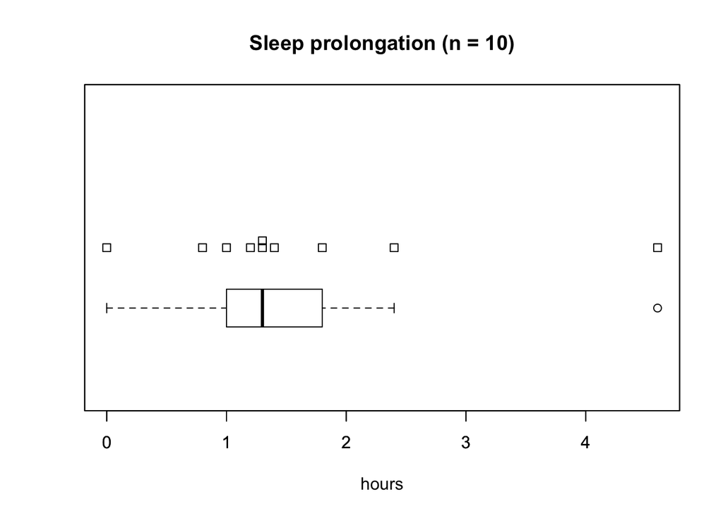

```r
stripchart(sleep1, method = "stack", xlab = "hours",
           main = "Sleep prolongation (n = 10)")
boxplot(sleep1, horizontal = TRUE, add = TRUE,
        at = .6, pars = list(boxwex = 0.5, staplewex = 0.25))
```

# t.test의 해석

http://r-graph.com:3838/ttest

# long form <-> wide form

학생 10명이 있다. 수업전 test 결과를 pre, 수업후 test결과를 post라고 하자

```r
id=1:10
pre=c(70,72,80,85,90,90,60,55,80,90)
post=c(80,73,84,90,95,85,60,50,84,100)
data=data.frame(id,pre,post)
data
```

```
   id pre post
1   1  70   80
2   2  72   73
3   3  80   84
4   4  85   90
5   5  90   95
6   6  90   85
7   7  60   60
8   8  55   50
9   9  80   84
10 10  90  100
```

이 데이타는 전형적인 wide form이다. 이 데이타를 long form으로 바꾸려면 gather()를 사용한다.

```r
require(tidyverse)
longdata=gather(data,key=key,value=value,-id)
longdata
```

```
   id  key value
1   1  pre    70
2   2  pre    72
3   3  pre    80
4   4  pre    85
5   5  pre    90
6   6  pre    90
7   7  pre    60
8   8  pre    55
9   9  pre    80
10 10  pre    90
11  1 post    80
12  2 post    73
13  3 post    84
14  4 post    90
15  5 post    95
16  6 post    85
17  7 post    60
18  8 post    50
19  9 post    84
20 10 post   100
```

long form의 데이타를 wide form의 데이타로 바꾸려면 spread()를 사용한다.

```r
widedata=spread(longdata,key,value)
widedata
```

```
   id post pre
1   1   80  70
2   2   73  72
3   3   84  80
4   4   90  85
5   5   95  90
6   6   85  90
7   7   60  60
8   8   50  55
9   9   84  80
10 10  100  90
```

# 두 집단의 평균의 비교

1. 정규성검정
- 반응변수가 정규분포 하는 경우 : 모수통계
- 그외 : 비모수통계

정규분포 하는경우

2. 분산이 같은지 검정( var.test() )
3. 분산이 다르면 Welch의 t-test 검정(t.test())
4. 분산이 같으면 pooled variance를 이용한 t-test (var.equal=TRUE)

### 반응변수의 정규성 검정 :

선형모형에 적합시킨후 잔차가 정규분포하는지 검정

```r
model=lm(age~sex,data=acs)
shapiro.test(resid(model))
```

```
    Shapiro-Wilk normality test

data:  resid(model)
W = 0.99343, p-value = 0.000808
```

```r
result=aggregate(age~sex,data=acs,function(x) { c(mean(x),sd(x))})
colnames(result$age)=c("mean","sd")
result
```

```
     sex age.mean   age.sd
1 Female 68.67596 10.73242
2   Male 60.61053 11.22885
```

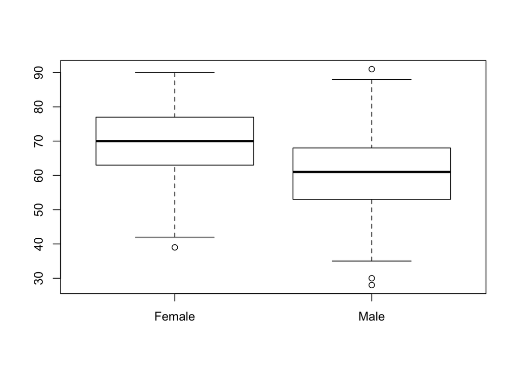

```r
boxplot(age~sex,data=acs)
```

```r
# 분산이 같은지 F 검정
var.test(age~sex,data=acs)
```

```
    F test to compare two variances

data:  age by sex
F = 0.91353, num df = 286, denom df = 569, p-value = 0.3866
alternative hypothesis: true ratio of variances is not equal to 1
95 percent confidence interval:
 0.7495537 1.1209741
sample estimates:
ratio of variances
         0.9135342
```

```r
require(webr)
```

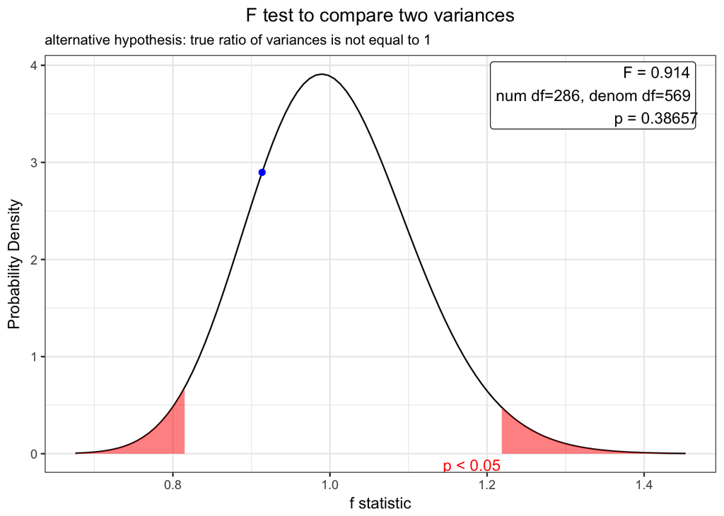

```r
plot(var.test(age~sex,data=acs))
```

```r
# 분산이 같으므로 var.equal=TRUE로 검정
result=t.test(age~sex,data=acs,var.equal=TRUE)
result
```

```
    Two Sample t-test

data:  age by sex
t = 10.071, df = 855, p-value < 2.2e-16
alternative hypothesis: true difference in means is not equal to 0
95 percent confidence interval:
 6.493487 9.637377
sample estimates:
mean in group Female   mean in group Male
            68.67596             60.61053
```

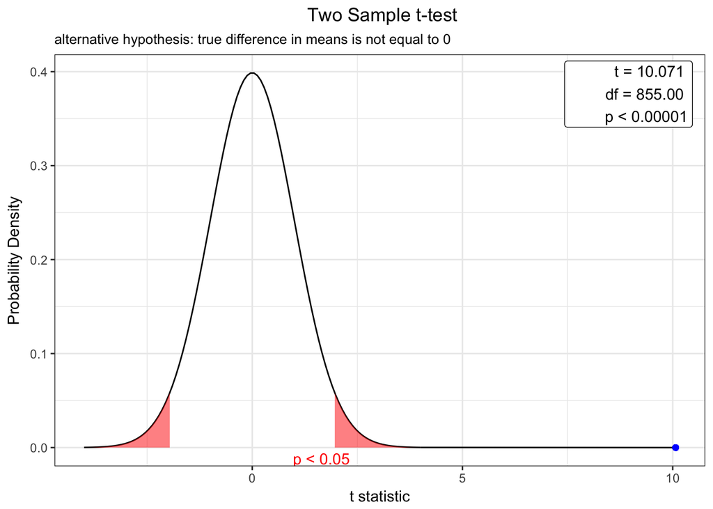

```r
plot(result)
```

```r
# 분산이 다르다면 var.equal=FALSE로 검정
t.test(age~sex,data=acs,var.equal=FALSE)
```

```
    Welch Two Sample t-test

data:  age by sex
t = 10.222, df = 596.99, p-value < 2.2e-16
alternative hypothesis: true difference in means is not equal to 0
95 percent confidence interval:
 6.515847 9.615016
sample estimates:
mean in group Female   mean in group Male
            68.67596             60.61053
```

```r
# 비모수검정
wilcox.test(age~sex,data=acs)
```

```
    Wilcoxon rank sum test with continuity correction

data:  age by sex
W = 115270, p-value < 2.2e-16
alternative hypothesis: true location shift is not equal to 0
```

# 일원분산분석 (One-way ANOVA)

```r
aggregate(mpg~cyl,data=mtcars,mean)
```

```
  cyl      mpg
1   4 26.66364
2   6 19.74286
3   8 15.10000
```

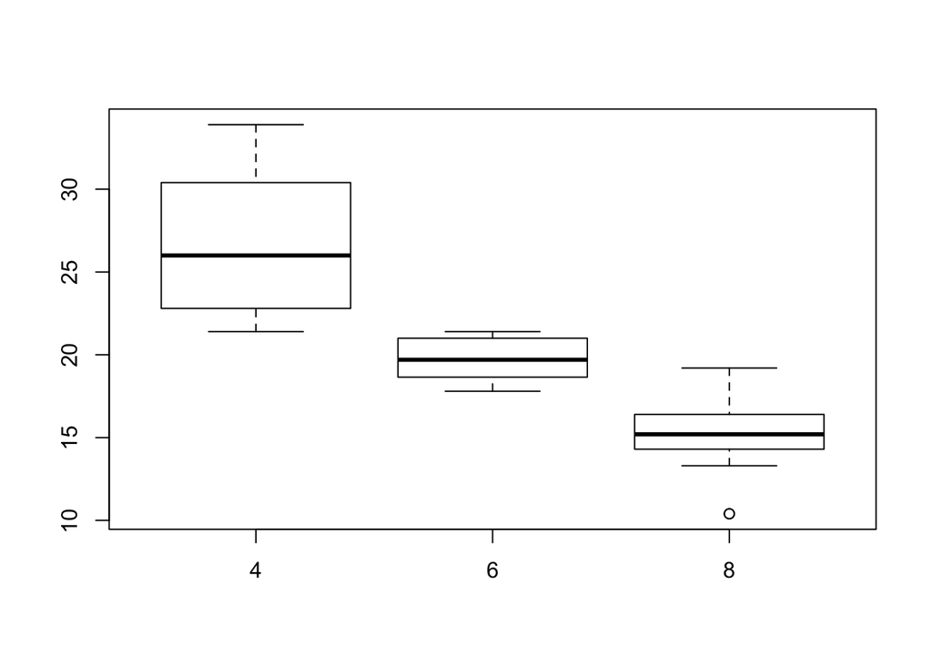

```r
boxplot(mpg~cyl,data=mtcars)
```

```r
# cyl가 numeric이므로 factor변수로 바꾸어준다
mtcars$group=factor(mtcars$cyl)
out=lm(mpg~group,data=mtcars)
out
```

```
Call:
lm(formula = mpg ~ group, data = mtcars)

Coefficients:
(Intercept)       group6       group8
     26.664       -6.921      -11.564
```

```r
anova(out)
```

```
Analysis of Variance Table

Response: mpg
          Df Sum Sq Mean Sq F value    Pr(>F)
group      2 824.78  412.39  39.697 4.979e-09 ***
Residuals 29 301.26   10.39
---
Signif. codes:  0 '***' 0.001 '**' 0.01 '*' 0.05 '.' 0.1 ' ' 1
```

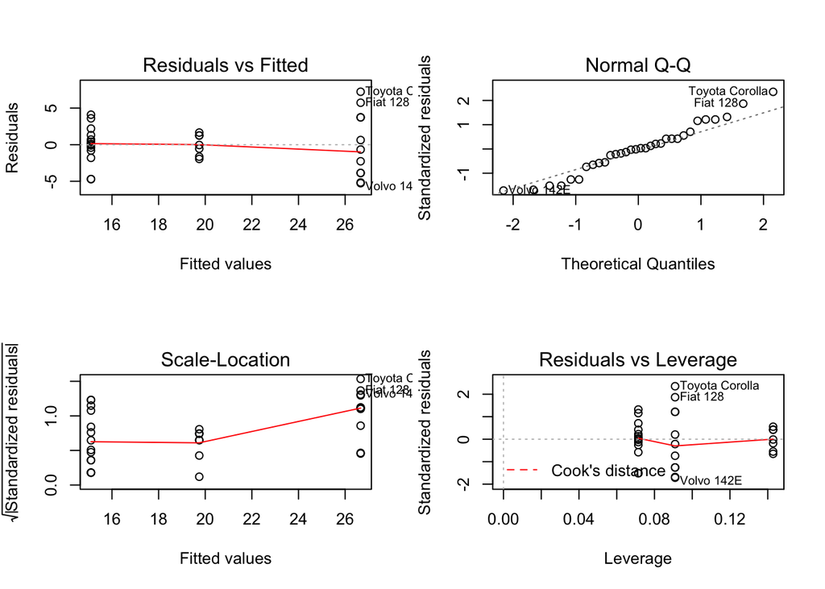

```r
par(mfrow=c(2,2))
plot(out)
```

```r
par(mfrow=c(1,1))
```

# 다중비교

```r
#install.packages("multcomp")
library(multcomp)
tukey=glht(out,linfct=mcp(group="Tukey"))
summary(tukey)
```

```
     Simultaneous Tests for General Linear Hypotheses

Multiple Comparisons of Means: Tukey Contrasts


Fit: lm(formula = mpg ~ group, data = mtcars)

Linear Hypotheses:
           Estimate Std. Error t value Pr(>|t|)
6 - 4 == 0   -6.921      1.558  -4.441 0.000319 ***
8 - 4 == 0  -11.564      1.299  -8.905  < 1e-04 ***
8 - 6 == 0   -4.643      1.492  -3.112 0.011026 *
---
Signif. codes:  0 '***' 0.001 '**' 0.01 '*' 0.05 '.' 0.1 ' ' 1
(Adjusted p values reported -- single-step method)
```

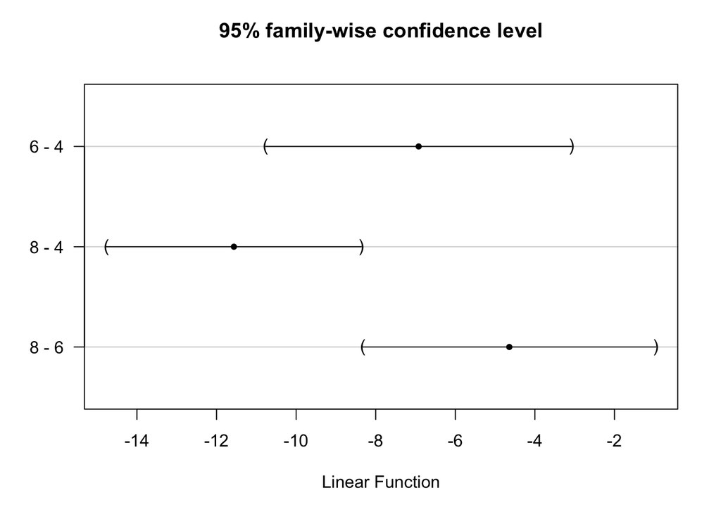

```r
plot(tukey)
```

# 비모수검정 : Kruskal-Wallis rank sum test

```r
kruskal.test(mpg~group,data=mtcars)
```

```
    Kruskal-Wallis rank sum test

data:  mpg by group
Kruskal-Wallis chi-squared = 25.746, df = 2, p-value = 2.566e-06
```

# 이원분산분석(Two-way ANOVA)

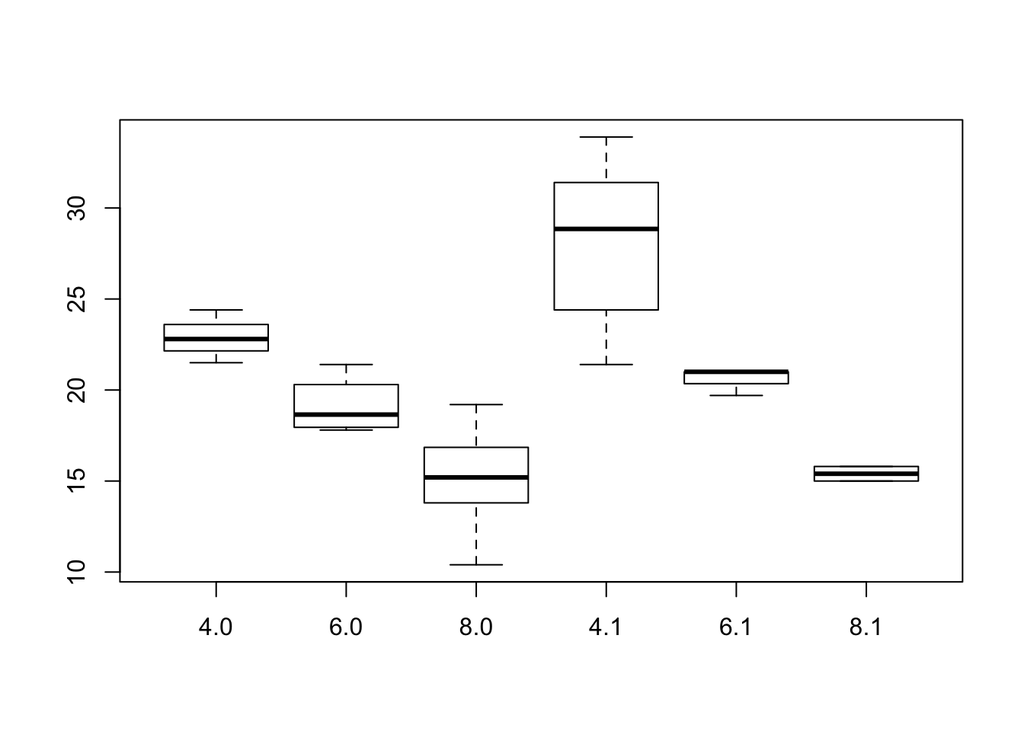

```r
boxplot(mpg~group+am,data=mtcars)
```

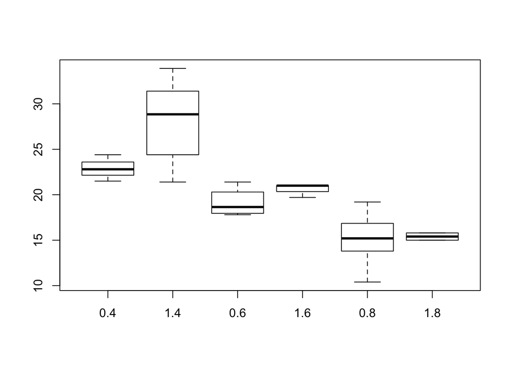

```r
boxplot(mpg~am+group,data=mtcars)
```

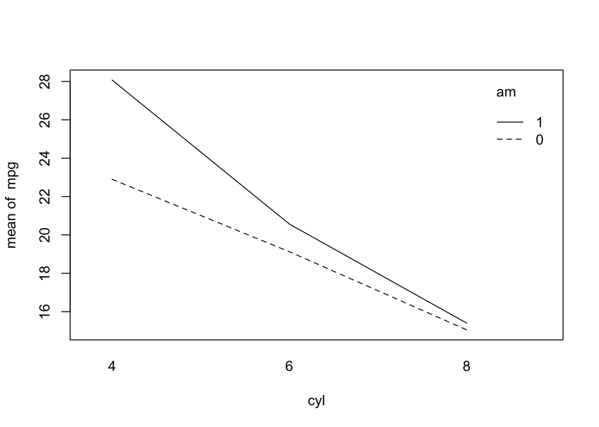

```r
with(mtcars,interaction.plot(cyl,am,mpg))
```

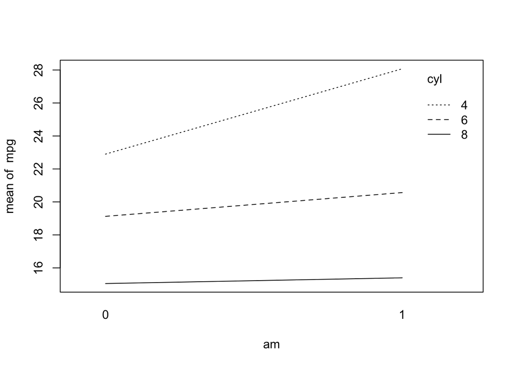

```r
with(mtcars,interaction.plot(am,cyl,mpg))
```

```r
out=lm(mpg~group+am,data=mtcars)
summary(out)
```

```
Call:
lm(formula = mpg ~ group + am, data = mtcars)

Residuals:
    Min      1Q  Median      3Q     Max
-5.9618 -1.4971 -0.2057  1.8907  6.5382

Coefficients:
            Estimate Std. Error t value Pr(>|t|)
(Intercept)   24.802      1.323  18.752  < 2e-16 ***
group6        -6.156      1.536  -4.009 0.000411 ***
group8       -10.068      1.452  -6.933 1.55e-07 ***
am             2.560      1.298   1.973 0.058457 .
---
Signif. codes:  0 '***' 0.001 '**' 0.01 '*' 0.05 '.' 0.1 ' ' 1

Residual standard error: 3.073 on 28 degrees of freedom
Multiple R-squared:  0.7651,    Adjusted R-squared:  0.7399
F-statistic:  30.4 on 3 and 28 DF,  p-value: 5.959e-09
```

# 공분산분석 (ANCOVA)

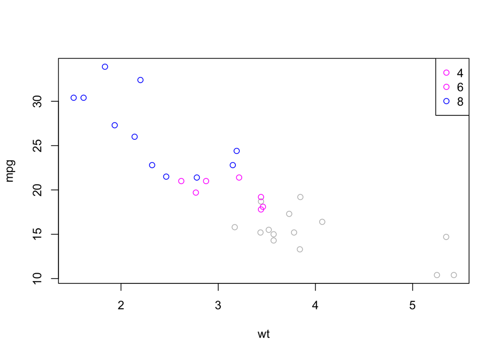

```r
plot(mpg~wt,data=mtcars,col=cyl)
legend("topright",legend=c("4","6","8"),pch=1,col=mtcars$cyl)
```

```r
out=lm(mpg~wt+group,data=mtcars)
anova(out)
```

```
Analysis of Variance Table

Response: mpg
          Df Sum Sq Mean Sq  F value    Pr(>F)
wt         1 847.73  847.73 129.6650 5.079e-12 ***
group      2  95.26   47.63   7.2856  0.002835 **
Residuals 28 183.06    6.54
---
Signif. codes:  0 '***' 0.001 '**' 0.01 '*' 0.05 '.' 0.1 ' ' 1
```

```r
summary(out)
```

```
Call:
lm(formula = mpg ~ wt + group, data = mtcars)

Residuals:
    Min      1Q  Median      3Q     Max
-4.5890 -1.2357 -0.5159  1.3845  5.7915

Coefficients:
            Estimate Std. Error t value Pr(>|t|)
(Intercept)  33.9908     1.8878  18.006  < 2e-16 ***
wt           -3.2056     0.7539  -4.252 0.000213 ***
group6       -4.2556     1.3861  -3.070 0.004718 **
group8       -6.0709     1.6523  -3.674 0.000999 ***
---
Signif. codes:  0 '***' 0.001 '**' 0.01 '*' 0.05 '.' 0.1 ' ' 1

Residual standard error: 2.557 on 28 degrees of freedom
Multiple R-squared:  0.8374,    Adjusted R-squared:   0.82
F-statistic: 48.08 on 3 and 28 DF,  p-value: 3.594e-11
```

```r
dunnett=glht(out,linfct=mcp(group="Dunnett"))
summary(dunnett)
```

```
     Simultaneous Tests for General Linear Hypotheses

Multiple Comparisons of Means: Dunnett Contrasts


Fit: lm(formula = mpg ~ wt + group, data = mtcars)

Linear Hypotheses:
           Estimate Std. Error t value Pr(>|t|)
6 - 4 == 0   -4.256      1.386  -3.070  0.00867 **
8 - 4 == 0   -6.071      1.652  -3.674  0.00188 **
---
Signif. codes:  0 '***' 0.001 '**' 0.01 '*' 0.05 '.' 0.1 ' ' 1
(Adjusted p values reported -- single-step method)
```

```r
library(lattice)
```

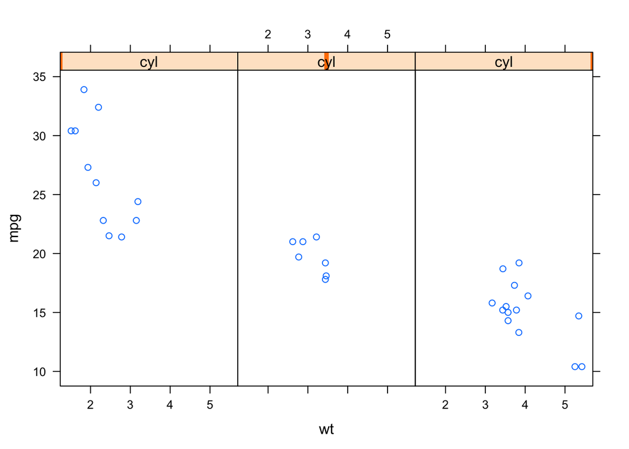

```r
xyplot(mpg~wt|cyl,data=mtcars)
```

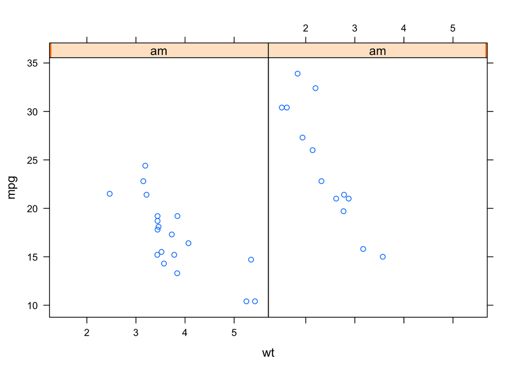

```r
xyplot(mpg~wt|am,data=mtcars)
```

# moonBook package 이용

그룹간의 비교를 한번에 : moonBook 패키지의 이용

```r
library(moonBook)
library(ztable)
str(acs)
```

```
'data.frame':   857 obs. of  17 variables:
 $ age             : int  62 78 76 89 56 73 58 62 59 71 ...
 $ sex             : chr  "Male" "Female" "Female" "Female" ...
 $ cardiogenicShock: chr  "No" "No" "Yes" "No" ...
 $ entry           : chr  "Femoral" "Femoral" "Femoral" "Femoral" ...
 $ Dx              : chr  "STEMI" "STEMI" "STEMI" "STEMI" ...
 $ EF              : num  18 18.4 20 21.8 21.8 22 24.7 26.6 28.5 31.1 ...
 $ height          : num  168 148 NA 165 162 153 167 160 152 168 ...
 $ weight          : num  72 48 NA 50 64 59 78 50 67 60 ...
 $ BMI             : num  25.5 21.9 NA 18.4 24.4 ...
 $ obesity         : chr  "Yes" "No" "No" "No" ...
 $ TC              : num  215 NA NA 121 195 184 161 136 239 169 ...
 $ LDLC            : int  154 NA NA 73 151 112 91 88 161 88 ...
 $ HDLC            : int  35 NA NA 20 36 38 34 33 34 54 ...
 $ TG              : int  155 166 NA 89 63 137 196 30 118 141 ...
 $ DM              : chr  "Yes" "No" "No" "No" ...
 $ HBP             : chr  "No" "Yes" "Yes" "No" ...
 $ smoking         : chr  "Smoker" "Never" "Never" "Never" ...
```

# mytable

```r
mytable(sex~age+DM,data=acs)
```

```
   Descriptive Statistics by 'sex'
______________________________________
           Female       Male       p
           (N=287)     (N=570)
--------------------------------------
 age     68.7 ± 10.7 60.6 ± 11.2 0.000
 DM                              0.077
   - No  173 (60.3%) 380 (66.7%)
   - Yes 114 (39.7%) 190 (33.3%)
--------------------------------------
```

```r
mytable(sex~.,data=acs)
```

```
          Descriptive Statistics by 'sex'
____________________________________________________
                        Female        Male       p
                       (N=287)      (N=570)
----------------------------------------------------
 age                 68.7 ± 10.7  60.6 ± 11.2  0.000
 cardiogenicShock                              0.136
   - No              275 (95.8%)  530 (93.0%)
   - Yes              12 ( 4.2%)   40 ( 7.0%)
 entry                                         0.035
   - Femoral         119 (41.5%)  193 (33.9%)
   - Radial          168 (58.5%)  377 (66.1%)
 Dx                                            0.012
   - NSTEMI           50 (17.4%)  103 (18.1%)
   - STEMI            84 (29.3%)  220 (38.6%)
   - Unstable Angina 153 (53.3%)  247 (43.3%)
 EF                  56.3 ± 10.1  55.6 ±  9.4  0.387
 height              153.8 ±  6.2 167.9 ±  6.1 0.000
 weight              57.2 ±  9.3  68.7 ± 10.3  0.000
 BMI                 24.2 ±  3.6  24.3 ±  3.2  0.611
 obesity                                       0.580
   - No              194 (67.6%)  373 (65.4%)
   - Yes              93 (32.4%)  197 (34.6%)
 TC                  188.9 ± 51.1 183.3 ± 45.9 0.124
 LDLC                117.8 ± 41.2 116.0 ± 41.1 0.561
 HDLC                39.0 ± 11.5  37.8 ± 10.9  0.145
 TG                  119.9 ± 76.2 127.9 ± 97.3 0.195
 DM                                            0.077
   - No              173 (60.3%)  380 (66.7%)
   - Yes             114 (39.7%)  190 (33.3%)
 HBP                                           0.000
   - No               83 (28.9%)  273 (47.9%)
   - Yes             204 (71.1%)  297 (52.1%)
 smoking                                       0.000
   - Ex-smoker        49 (17.1%)  155 (27.2%)
   - Never           209 (72.8%)  123 (21.6%)
   - Smoker           29 (10.1%)  292 (51.2%)
----------------------------------------------------
```

```r
mytable(sex~.-smoking,data=acs)
```

```
          Descriptive Statistics by 'sex'
____________________________________________________
                        Female        Male       p
                       (N=287)      (N=570)
----------------------------------------------------
 age                 68.7 ± 10.7  60.6 ± 11.2  0.000
 cardiogenicShock                              0.136
   - No              275 (95.8%)  530 (93.0%)
   - Yes              12 ( 4.2%)   40 ( 7.0%)
 entry                                         0.035
   - Femoral         119 (41.5%)  193 (33.9%)
   - Radial          168 (58.5%)  377 (66.1%)
 Dx                                            0.012
   - NSTEMI           50 (17.4%)  103 (18.1%)
   - STEMI            84 (29.3%)  220 (38.6%)
   - Unstable Angina 153 (53.3%)  247 (43.3%)
 EF                  56.3 ± 10.1  55.6 ±  9.4  0.387
 height              153.8 ±  6.2 167.9 ±  6.1 0.000
 weight              57.2 ±  9.3  68.7 ± 10.3  0.000
 BMI                 24.2 ±  3.6  24.3 ±  3.2  0.611
 obesity                                       0.580
   - No              194 (67.6%)  373 (65.4%)
   - Yes              93 (32.4%)  197 (34.6%)
 TC                  188.9 ± 51.1 183.3 ± 45.9 0.124
 LDLC                117.8 ± 41.2 116.0 ± 41.1 0.561
 HDLC                39.0 ± 11.5  37.8 ± 10.9  0.145
 TG                  119.9 ± 76.2 127.9 ± 97.3 0.195
 DM                                            0.077
   - No              173 (60.3%)  380 (66.7%)
   - Yes             114 (39.7%)  190 (33.3%)
 HBP                                           0.000
   - No               83 (28.9%)  273 (47.9%)
   - Yes             204 (71.1%)  297 (52.1%)
----------------------------------------------------
```

```r
res=mytable(Dx~.,data=acs)
res
```

```
                 Descriptive Statistics by 'Dx'
_________________________________________________________________
                     NSTEMI       STEMI     Unstable Angina   p
                    (N=153)      (N=304)        (N=400)
-----------------------------------------------------------------
 age              64.3 ± 12.3  62.1 ± 12.1    63.8 ± 11.0   0.073
 sex                                                        0.012
   - Female        50 (32.7%)   84 (27.6%)    153 (38.2%)
   - Male         103 (67.3%)  220 (72.4%)    247 (61.8%)
 cardiogenicShock                                           0.000
   - No           149 (97.4%)  256 (84.2%)   400 (100.0%)
   - Yes           4 ( 2.6%)    48 (15.8%)     0 ( 0.0%)
 entry                                                      0.001
   - Femoral       58 (37.9%)  133 (43.8%)    121 (30.2%)
   - Radial        95 (62.1%)  171 (56.2%)    279 (69.8%)
 EF               55.0 ±  9.3  52.4 ±  9.5    59.2 ±  8.7   0.000
 height           163.3 ±  8.2 165.1 ±  8.2  161.7 ±  9.7   0.000
 weight           64.3 ± 10.2  65.7 ± 11.6    64.5 ± 11.6   0.361
 BMI              24.1 ±  3.2  24.0 ±  3.3    24.6 ±  3.4   0.064
 obesity                                                    0.186
   - No           106 (69.3%)  209 (68.8%)    252 (63.0%)
   - Yes           47 (30.7%)   95 (31.2%)    148 (37.0%)
 TC               193.7 ± 53.6 183.2 ± 43.4  183.5 ± 48.3   0.057
 LDLC             126.1 ± 44.7 116.7 ± 39.5  112.9 ± 40.4   0.004
 HDLC             38.9 ± 11.9  38.5 ± 11.0    37.8 ± 10.9   0.501
 TG               130.1 ± 88.5 106.5 ± 72.0  137.4 ± 101.6  0.000
 DM                                                         0.209
   - No            96 (62.7%)  208 (68.4%)    249 (62.2%)
   - Yes           57 (37.3%)   96 (31.6%)    151 (37.8%)
 HBP                                                        0.002
   - No            62 (40.5%)  150 (49.3%)    144 (36.0%)
   - Yes           91 (59.5%)  154 (50.7%)    256 (64.0%)
 smoking                                                    0.000
   - Ex-smoker     42 (27.5%)   66 (21.7%)    96 (24.0%)
   - Never         50 (32.7%)   97 (31.9%)    185 (46.2%)
   - Smoker        61 (39.9%)  141 (46.4%)    119 (29.8%)
-----------------------------------------------------------------
```

# group변수를 중첩하여 사용

```r
mytable(Dx+sex~.,data=acs)
```

```
                                Descriptive Statistics stratified by 'Dx' and 'sex'
___________________________________________________________________________________________________________________
                                STEMI                            NSTEMI                        Unstable Angina
                  ------------------------------- -------------------------------- --------------------------------
                     Female        Male       p      Female        Male        p      Female        Male        p
                     (N=84)      (N=220)            (N=50)       (N=103)           (N=153)       (N=247)
-------------------------------------------------------------------------------------------------------------------
 age              69.1 ± 10.4  59.4 ± 11.7  0.000 70.9 ± 11.4   61.1 ± 11.6  0.000 67.7 ± 10.7   61.4 ± 10.6  0.000
 cardiogenicShock                           0.535                            1.000
   - No            73 (86.9%)  183 (83.2%)         49 (98.0%)   100 (97.1%)        153 (100.0%) 247 (100.0%)
   - Yes           11 (13.1%)   37 (16.8%)         1 ( 2.0%)     3 ( 2.9%)           0 ( 0.0%)    0 ( 0.0%)
 entry                                      0.045                            0.366                            0.243
   - Femoral       45 (53.6%)   88 (40.0%)         22 (44.0%)   36 (35.0%)          52 (34.0%)   69 (27.9%)
   - Radial        39 (46.4%)  132 (60.0%)         28 (56.0%)   67 (65.0%)         101 (66.0%)   178 (72.1%)
 EF               52.3 ± 10.9  52.4 ±  8.9  0.970 54.8 ±  9.1   55.1 ±  9.4  0.891 59.4 ±  8.8   59.1 ±  8.7  0.798
 height           155.7 ±  5.4 168.7 ±  6.0 0.000 154.2 ±  5.1 167.5 ±  5.7  0.000 152.6 ±  6.7 167.3 ±  6.4  0.000
 weight           57.4 ±  9.0  68.8 ± 10.9  0.000 57.2 ± 10.3   67.5 ±  8.4  0.000 57.1 ±  9.1   69.0 ± 10.6  0.000
 BMI              23.6 ±  3.2  24.1 ±  3.4  0.282 24.1 ±  4.3   24.1 ±  2.6  0.967 24.5 ±  3.5   24.6 ±  3.4  0.816
 obesity                                    0.628                            1.000                            0.653
   - No            60 (71.4%)  149 (67.7%)         35 (70.0%)   71 (68.9%)          99 (64.7%)   153 (61.9%)
   - Yes           24 (28.6%)   71 (32.3%)         15 (30.0%)   32 (31.1%)          54 (35.3%)   94 (38.1%)
 TC               180.7 ± 45.7 184.1 ± 42.6 0.542 196.3 ± 52.7 192.6 ± 54.3  0.697 191.1 ± 53.1 178.7 ± 44.6  0.018
 LDLC             111.0 ± 40.0 118.9 ± 39.1 0.128 127.7 ± 39.5 125.4 ± 47.1  0.774 118.3 ± 41.8 109.5 ± 39.2  0.035
 HDLC             39.5 ± 11.2  38.1 ± 10.9  0.338 40.1 ± 13.8   38.4 ± 10.9  0.414 38.5 ± 10.8   37.4 ± 10.9  0.338
 TG               112.3 ± 87.2 104.3 ± 65.5 0.454 112.5 ± 51.1 138.0 ± 100.2 0.042 126.3 ± 76.0 144.3 ± 114.2 0.060
 DM                                         0.412                            0.036                            0.875
   - No            54 (64.3%)  154 (70.0%)         25 (50.0%)   71 (68.9%)          94 (61.4%)   155 (62.8%)
   - Yes           30 (35.7%)   66 (30.0%)         25 (50.0%)   32 (31.1%)          59 (38.6%)   92 (37.2%)
 HBP                                        0.001                            0.789                            0.000
   - No            28 (33.3%)  122 (55.5%)         19 (38.0%)   43 (41.7%)          36 (23.5%)   108 (43.7%)
   - Yes           56 (66.7%)   98 (44.5%)         31 (62.0%)   60 (58.3%)         117 (76.5%)   139 (56.3%)
 smoking                                    0.000                            0.000                            0.000
   - Ex-smoker     13 (15.5%)   53 (24.1%)         8 (16.0%)    34 (33.0%)          28 (18.3%)   68 (27.5%)
   - Never         57 (67.9%)   40 (18.2%)         37 (74.0%)   13 (12.6%)         115 (75.2%)   70 (28.3%)
   - Smoker        14 (16.7%)  127 (57.7%)         5 (10.0%)    56 (54.4%)          10 ( 6.5%)   109 (44.1%)
-------------------------------------------------------------------------------------------------------------------
```

# ztable과의 연동

```r
z=ztable(res)
print(z,type="html")
```

|  | NSTEMI | STEMI | Unstable Angina | p |  |
| --- | --- | --- | --- | --- | --- |
|  | (N=153) | (N=304) | (N=400) |  |  |
| age | 64.3 ± 12.3 | 62.1 ± 12.1 | 63.8 ± 11.0 |  | 0.073 |
| sex |  |  |  | 0.012 |  |
| Female | 50 (32.7%) | 84 (27.6%) | 153 (38.2%) |  |  |
| Male | 103 (67.3%) | 220 (72.4%) | 247 (61.8%) |  |  |
| cardiogenicShock |  |  |  | 0.000 |  |
| No | 149 (97.4%) | 256 (84.2%) | 400 (100.0%) |  |  |
| Yes | 4 ( 2.6%) | 48 (15.8%) | 0 ( 0.0%) |  |  |
| entry |  |  |  | 0.001 |  |
| Femoral | 58 (37.9%) | 133 (43.8%) | 121 (30.2%) |  |  |
| Radial | 95 (62.1%) | 171 (56.2%) | 279 (69.8%) |  |  |
| EF | 55.0 ± 9.3 | 52.4 ± 9.5 | 59.2 ± 8.7 | 0.000 |  |
| height | 163.3 ± 8.2 | 165.1 ± 8.2 | 161.7 ± 9.7 | 0.000 |  |
| weight | 64.3 ± 10.2 | 65.7 ± 11.6 | 64.5 ± 11.6 | 0.361 |  |
| BMI | 24.1 ± 3.2 | 24.0 ± 3.3 | 24.6 ± 3.4 | 0.064 |  |
| obesity |  |  |  | 0.186 |  |
| No | 106 (69.3%) | 209 (68.8%) | 252 (63.0%) |  |  |
| Yes | 47 (30.7%) | 95 (31.2%) | 148 (37.0%) |  |  |
| TC | 193.7 ± 53.6 | 183.2 ± 43.4 | 183.5 ± 48.3 | 0.057 |  |
| LDLC | 126.1 ± 44.7 | 116.7 ± 39.5 | 112.9 ± 40.4 | 0.004 |  |
| HDLC | 38.9 ± 11.9 | 38.5 ± 11.0 | 37.8 ± 10.9 | 0.501 |  |
| TG | 130.1 ± 88.5 | 106.5 ± 72.0 | 137.4 ± 101.6 | 0.000 |  |
| DM |  |  |  | 0.209 |  |
| No | 96 (62.7%) | 208 (68.4%) | 249 (62.2%) |  |  |
| Yes | 57 (37.3%) | 96 (31.6%) | 151 (37.8%) |  |  |
| HBP |  |  |  | 0.002 |  |
| No | 62 (40.5%) | 150 (49.3%) | 144 (36.0%) |  |  |
| Yes | 91 (59.5%) | 154 (50.7%) | 256 (64.0%) |  |  |
| smoking |  |  |  | 0.000 |  |
| Ex-smoker | 42 (27.5%) | 66 (21.7%) | 96 (24.0%) |  |  |
| Never | 50 (32.7%) | 97 (31.9%) | 185 (46.2%) |  |  |
| Smoker | 61 (39.9%) | 141 (46.4%) | 119 (29.8%) |  |  |